# Lab 8: Linear Classifiers

Author

Shawheen Ghezavat

[View this project on GitHub](https://github.com/shxwheen/msba-ml-labs/tree/main/lab8)

```python
import warnings
warnings.filterwarnings('ignore')

import pandas as pd
import numpy as np
from sklearn.model_selection import cross_val_score, GridSearchCV
from sklearn.preprocessing import StandardScaler
from sklearn.pipeline import Pipeline
from sklearn.discriminant_analysis import LinearDiscriminantAnalysis, QuadraticDiscriminantAnalysis
from sklearn.svm import SVC
from sklearn.neighbors import KNeighborsClassifier
from sklearn.tree import DecisionTreeClassifier, plot_tree
from sklearn.linear_model import LogisticRegression
from sklearn.metrics import confusion_matrix, ConfusionMatrixDisplay
import matplotlib.pyplot as plt
```

# The Data

```python
df = pd.read_csv("cannabis_full.csv")
df = df.dropna()
df.head()
```

|  | Strain | Type | Rating | Effects | Flavor | Creative | Energetic | Tingly | Euphoric | Relaxed | ... | Ammonia | Minty | Tree | Fruit | Butter | Pineapple | Tar | Rose | Plum | Pear |
| --- | --- | --- | --- | --- | --- | --- | --- | --- | --- | --- | --- | --- | --- | --- | --- | --- | --- | --- | --- | --- | --- |
| 0 | 100-Og | hybrid | 4.0 | Creative,Energetic,Tingly,Euphoric,Relaxed | Earthy,Sweet,Citrus | 1.0 | 1.0 | 1.0 | 1.0 | 1.0 | ... | 0.0 | 0.0 | 0.0 | 0.0 | 0.0 | 0.0 | 0.0 | 0.0 | 0.0 | 0.0 |
| 1 | 98-White-Widow | hybrid | 4.7 | Relaxed,Aroused,Creative,Happy,Energetic | Flowery,Violet,Diesel | 1.0 | 1.0 | 0.0 | 0.0 | 1.0 | ... | 0.0 | 0.0 | 0.0 | 0.0 | 0.0 | 0.0 | 0.0 | 0.0 | 0.0 | 0.0 |
| 2 | 1024 | sativa | 4.4 | Uplifted,Happy,Relaxed,Energetic,Creative | Spicy/Herbal,Sage,Woody | 1.0 | 1.0 | 0.0 | 0.0 | 1.0 | ... | 0.0 | 0.0 | 0.0 | 0.0 | 0.0 | 0.0 | 0.0 | 0.0 | 0.0 | 0.0 |
| 3 | 13-Dawgs | hybrid | 4.2 | Tingly,Creative,Hungry,Relaxed,Uplifted | Apricot,Citrus,Grapefruit | 1.0 | 0.0 | 1.0 | 0.0 | 1.0 | ... | 0.0 | 0.0 | 0.0 | 0.0 | 0.0 | 0.0 | 0.0 | 0.0 | 0.0 | 0.0 |
| 4 | 24K-Gold | hybrid | 4.6 | Happy,Relaxed,Euphoric,Uplifted,Talkative | Citrus,Earthy,Orange | 0.0 | 0.0 | 0.0 | 1.0 | 1.0 | ... | 0.0 | 0.0 | 0.0 | 0.0 | 0.0 | 0.0 | 0.0 | 0.0 | 0.0 | 0.0 |

5 rows × 69 columns

```python
# Check class distribution
df['Type'].value_counts()
```

```
Type
hybrid    1123
indica     659
sativa     409
Name: count, dtype: int64
```

# Part One: Binary Classification

Create dataset with only Sativa and Indica strains.

```python
df_binary = df[df['Type'].isin(['sativa', 'indica'])].copy()
df_binary['Type'].value_counts()
```

```
Type
indica    659
sativa    409
Name: count, dtype: int64
```

```python
# Set up X and y for binary classification
X_binary = df_binary.drop(columns=['Strain', 'Type', 'Rating', 'Effects', 'Flavor'])
y_binary = df_binary['Type']
```

**Metric Choice:** I will use **accuracy** because we care equally about identifying both classes and there’s no specific target to prioritize.

## Q1: LDA

```python
lda_model = Pipeline([
    ("scale", StandardScaler()),
    ("model", LinearDiscriminantAnalysis())
])

lda_cv = cross_val_score(lda_model, X_binary, y_binary, cv=5, scoring="accuracy")
print(f"LDA CV Accuracy: {lda_cv.mean():.4f}")
```

```
LDA CV Accuracy: 0.8567
```

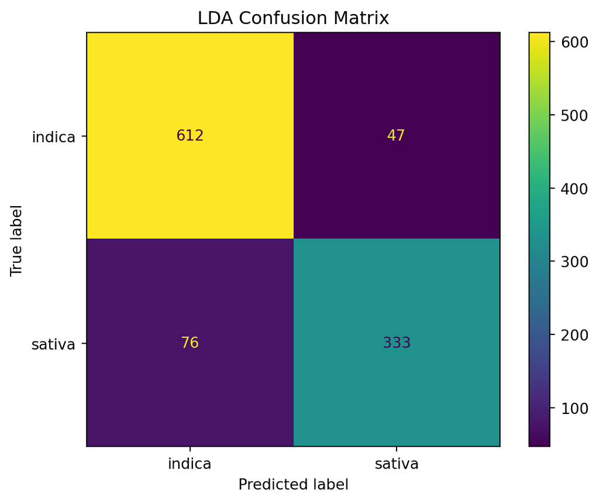

```python
# Fit final model and confusion matrix
lda_model.fit(X_binary, y_binary)
lda_pred = lda_model.predict(X_binary)
ConfusionMatrixDisplay.from_predictions(y_binary, lda_pred)
plt.title("LDA Confusion Matrix")
plt.show()
```

## Q2: QDA

```python
qda_model = Pipeline([
    ("scale", StandardScaler()),
    ("model", QuadraticDiscriminantAnalysis())
])

qda_cv = cross_val_score(qda_model, X_binary, y_binary, cv=5, scoring="accuracy")
print(f"QDA CV Accuracy: {qda_cv.mean():.4f}")
```

```
QDA CV Accuracy: 0.5000
```

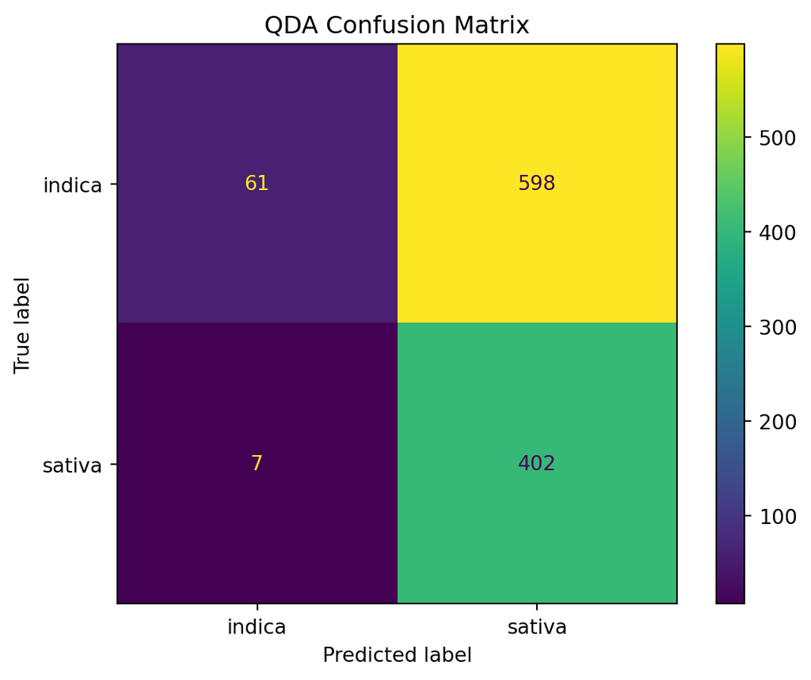

```python
qda_model.fit(X_binary, y_binary)
qda_pred = qda_model.predict(X_binary)
ConfusionMatrixDisplay.from_predictions(y_binary, qda_pred)
plt.title("QDA Confusion Matrix")
plt.show()
```

## Q3: SVC

```python
svc_pipeline = Pipeline([
    ("scale", StandardScaler()),
    ("model", SVC(kernel="linear"))
])

param_grid = {'model__C': [0.01, 0.1, 1, 10, 100]}

svc_grid = GridSearchCV(svc_pipeline, param_grid, cv=5, scoring="accuracy")
svc_grid.fit(X_binary, y_binary)

print(f"Best C: {svc_grid.best_params_}")
print(f"SVC CV Accuracy: {svc_grid.best_score_:.4f}")
```

```
Best C: {'model__C': 0.1}
SVC CV Accuracy: 0.8586
```

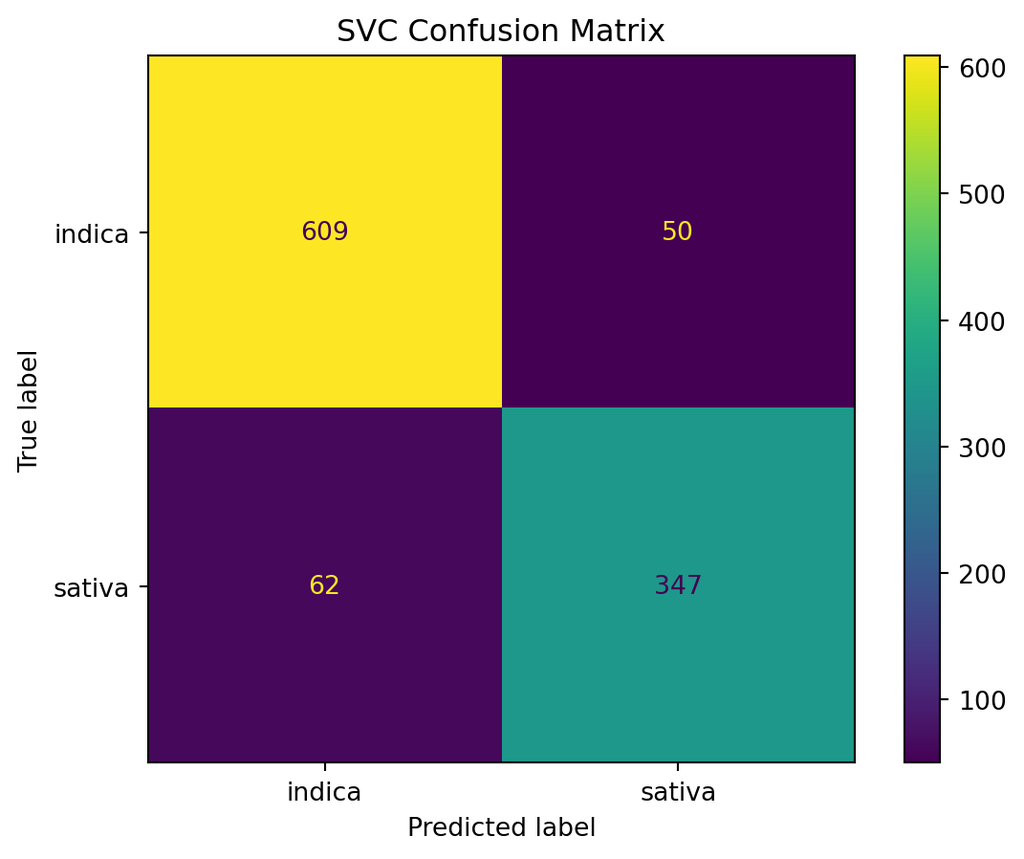

```python
svc_best = svc_grid.best_estimator_
svc_pred = svc_best.predict(X_binary)
ConfusionMatrixDisplay.from_predictions(y_binary, svc_pred)
plt.title("SVC Confusion Matrix")
plt.show()
```

## Q4: SVM (Polynomial Kernel)

```python
svm_pipeline = Pipeline([
    ("scale", StandardScaler()),
    ("model", SVC(kernel="poly"))
])

param_grid = {
    'model__C': [0.1, 1, 10],
    'model__degree': [2, 3]
}

svm_grid = GridSearchCV(svm_pipeline, param_grid, cv=5, scoring="accuracy")
svm_grid.fit(X_binary, y_binary)

print(f"Best params: {svm_grid.best_params_}")
print(f"SVM CV Accuracy: {svm_grid.best_score_:.4f}")
```

```
Best params: {'model__C': 10, 'model__degree': 3}
SVM CV Accuracy: 0.8409
```

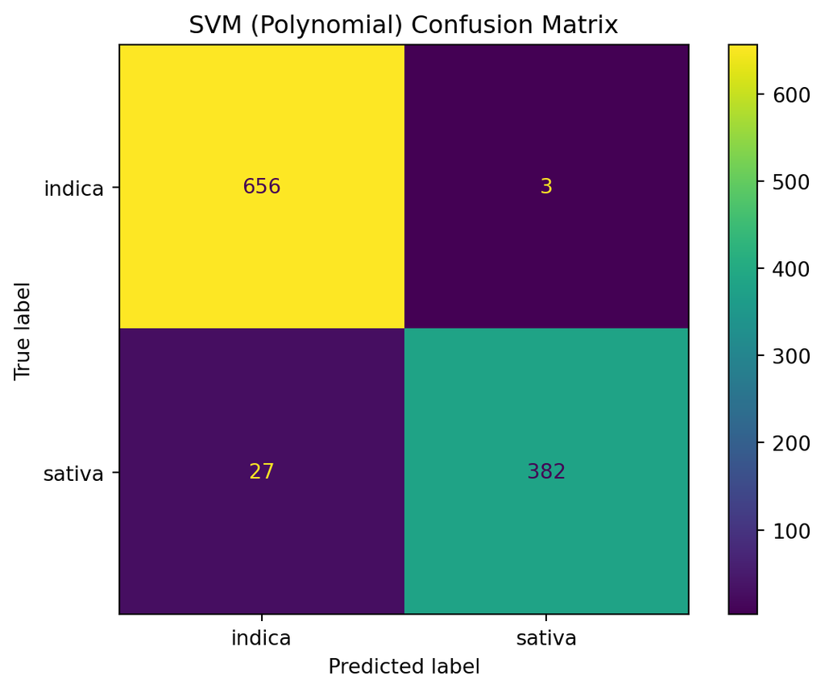

```python
svm_best = svm_grid.best_estimator_
svm_pred = svm_best.predict(X_binary)
ConfusionMatrixDisplay.from_predictions(y_binary, svm_pred)
plt.title("SVM (Polynomial) Confusion Matrix")
plt.show()
```

# Part Two: Natural Multiclass

Now use the full dataset including Hybrid strains.

```python
X_full = df.drop(columns=['Strain', 'Type', 'Rating', 'Effects', 'Flavor'])
y_full = df['Type']
```

## Q1: Decision Tree

```python
dt_model = Pipeline([
    ("scale", StandardScaler()),
    ("model", DecisionTreeClassifier(max_depth=3, random_state=42))
])

dt_cv = cross_val_score(dt_model, X_full, y_full, cv=5, scoring="accuracy")
print(f"Decision Tree CV Accuracy: {dt_cv.mean():.4f}")
```

```
Decision Tree CV Accuracy: 0.6198
```

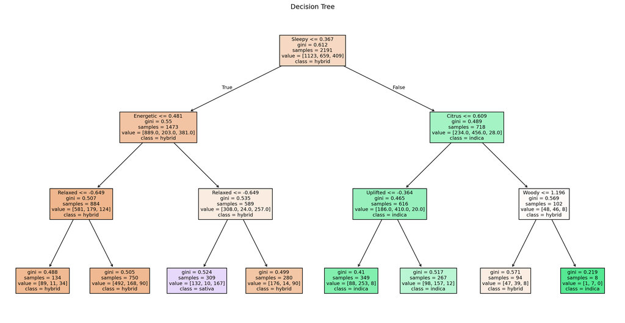

```python
dt_model.fit(X_full, y_full)
plt.figure(figsize=(20, 10))
plot_tree(dt_model.named_steps["model"],
          feature_names=X_full.columns,
          class_names=['hybrid', 'indica', 'sativa'],
          filled=True)
plt.title("Decision Tree")
plt.show()
```

**Interpretation:** The tree first splits on Sleepy, making it the most important feature. Strains without the Sleepy effect (left branch) are further split by Energetic and Relaxed, leading mostly to Hybrid or Sativa classifications. Strains with the Sleepy effect (right branch) are split by Citrus and Uplifted, leading mostly to Indica. This aligns with the known characteristics of cannabis types: Indica strains tend to be relaxing/sleepy, while Sativa strains tend to be energetic.

## Q2: LDA, QDA, KNN

### LDA (Multiclass)

```python
lda_multi = Pipeline([
    ("scale", StandardScaler()),
    ("model", LinearDiscriminantAnalysis())
])

lda_multi_cv = cross_val_score(lda_multi, X_full, y_full, cv=5, scoring="accuracy")
print(f"LDA CV Accuracy: {lda_multi_cv.mean():.4f}")
```

```
LDA CV Accuracy: 0.6280
```

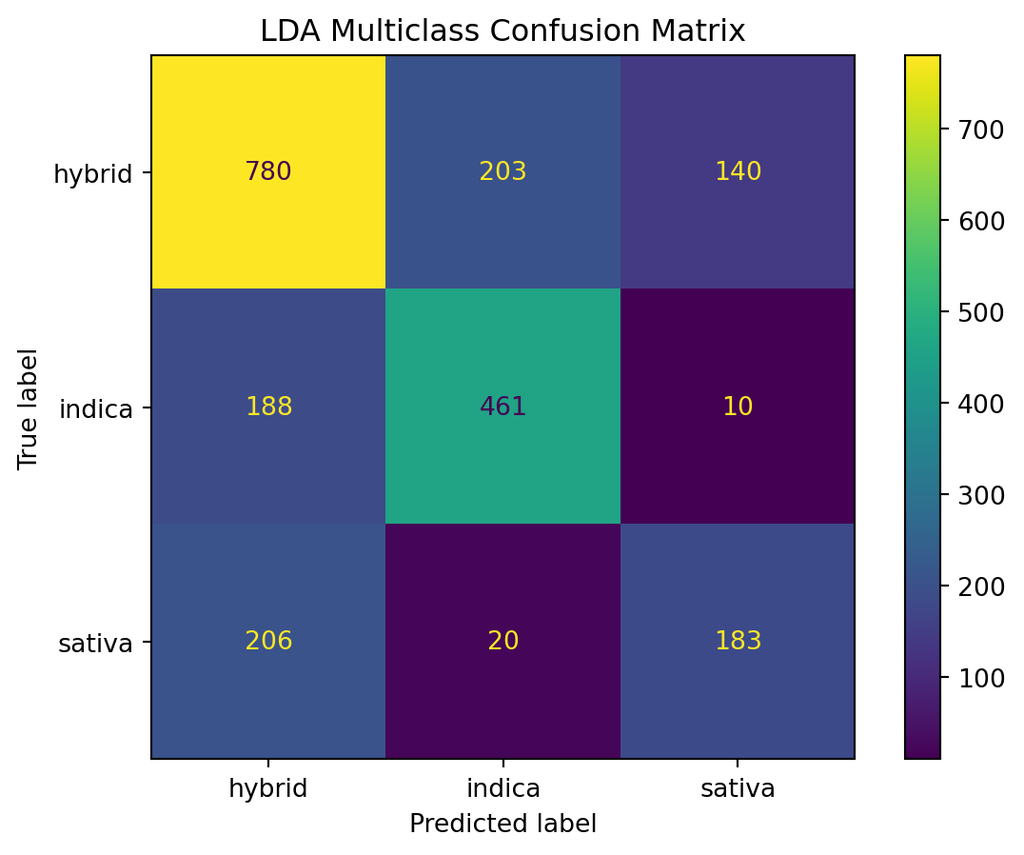

```python
lda_multi.fit(X_full, y_full)
lda_multi_pred = lda_multi.predict(X_full)
ConfusionMatrixDisplay.from_predictions(y_full, lda_multi_pred)
plt.title("LDA Multiclass Confusion Matrix")
plt.show()
```

### QDA (Multiclass)

```python
qda_multi = Pipeline([
    ("scale", StandardScaler()),
    ("model", QuadraticDiscriminantAnalysis())
])

qda_multi_cv = cross_val_score(qda_multi, X_full, y_full, cv=5, scoring="accuracy")
print(f"QDA CV Accuracy: {qda_multi_cv.mean():.4f}")
```

```
QDA CV Accuracy: 0.2305
```

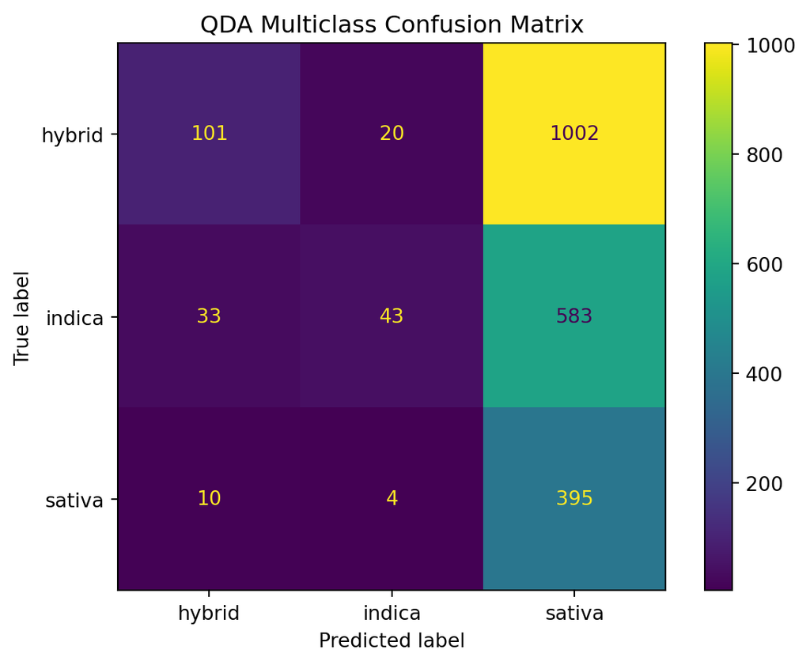

```python
qda_multi.fit(X_full, y_full)
qda_multi_pred = qda_multi.predict(X_full)
ConfusionMatrixDisplay.from_predictions(y_full, qda_multi_pred)
plt.title("QDA Multiclass Confusion Matrix")
plt.show()
```

### KNN (Multiclass)

```python
knn_pipeline = Pipeline([
    ("scale", StandardScaler()),
    ("model", KNeighborsClassifier())
])

param_grid = {'model__n_neighbors': [3, 5, 7, 9, 11]}

knn_grid = GridSearchCV(knn_pipeline, param_grid, cv=5, scoring="accuracy")
knn_grid.fit(X_full, y_full)

print(f"Best K: {knn_grid.best_params_}")
print(f"KNN CV Accuracy: {knn_grid.best_score_:.4f}")
```

```
Best K: {'model__n_neighbors': 11}
KNN CV Accuracy: 0.5509
```

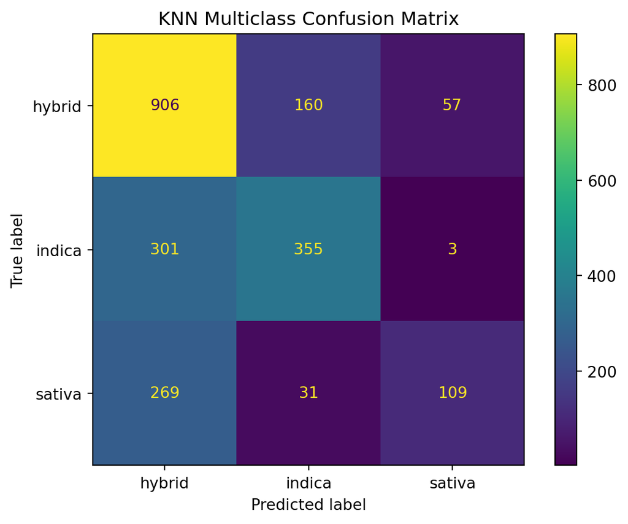

```python
knn_best = knn_grid.best_estimator_
knn_pred = knn_best.predict(X_full)
ConfusionMatrixDisplay.from_predictions(y_full, knn_pred)
plt.title("KNN Multiclass Confusion Matrix")
plt.show()
```

## Q3: Comparison

The confusion matrices show that Hybrid was most often confused with other categories, while Indica and Sativa were rarely misclassified as each other. This makes sense because Hybrid strains are a mix of both types and share features with each, while Indica and Sativa have more distinct profiles.

# Part Three: Multiclass from Binary

## Q1: OvR Models

### SVC OvR

```python
# Indica vs Not Indica
y_indica = (y_full == 'indica').astype(int)
svc_indica = Pipeline([("scale", StandardScaler()), ("model", SVC(kernel="linear"))])
svc_indica_cv = cross_val_score(svc_indica, X_full, y_indica, cv=5, scoring="f1")
print(f"SVC Indica vs Rest F1: {svc_indica_cv.mean():.4f}")

# Sativa vs Not Sativa
y_sativa = (y_full == 'sativa').astype(int)
svc_sativa = Pipeline([("scale", StandardScaler()), ("model", SVC(kernel="linear"))])
svc_sativa_cv = cross_val_score(svc_sativa, X_full, y_sativa, cv=5, scoring="f1")
print(f"SVC Sativa vs Rest F1: {svc_sativa_cv.mean():.4f}")

# Hybrid vs Not Hybrid
y_hybrid = (y_full == 'hybrid').astype(int)
svc_hybrid = Pipeline([("scale", StandardScaler()), ("model", SVC(kernel="linear"))])
svc_hybrid_cv = cross_val_score(svc_hybrid, X_full, y_hybrid, cv=5, scoring="f1")
print(f"SVC Hybrid vs Rest F1: {svc_hybrid_cv.mean():.4f}")
```

```
SVC Indica vs Rest F1: 0.6614
SVC Sativa vs Rest F1: 0.2936
SVC Hybrid vs Rest F1: 0.6711
```

### Logistic Regression OvR

```python
# Indica vs Not Indica
lr_indica = Pipeline([("scale", StandardScaler()), ("model", LogisticRegression(max_iter=1000))])
lr_indica_cv = cross_val_score(lr_indica, X_full, y_indica, cv=5, scoring="f1")
print(f"LR Indica vs Rest F1: {lr_indica_cv.mean():.4f}")

# Sativa vs Not Sativa
lr_sativa = Pipeline([("scale", StandardScaler()), ("model", LogisticRegression(max_iter=1000))])
lr_sativa_cv = cross_val_score(lr_sativa, X_full, y_sativa, cv=5, scoring="f1")
print(f"LR Sativa vs Rest F1: {lr_sativa_cv.mean():.4f}")

# Hybrid vs Not Hybrid
lr_hybrid = Pipeline([("scale", StandardScaler()), ("model", LogisticRegression(max_iter=1000))])
lr_hybrid_cv = cross_val_score(lr_hybrid, X_full, y_hybrid, cv=5, scoring="f1")
print(f"LR Hybrid vs Rest F1: {lr_hybrid_cv.mean():.4f}")
```

```
LR Indica vs Rest F1: 0.6365
LR Sativa vs Rest F1: 0.4035
LR Hybrid vs Rest F1: 0.6368
```

## Q2: OvR Analysis

SVC Hybrid vs Rest performed best (F1 = 0.6711), while SVC Sativa vs Rest performed worst (F1 = 0.2936). This makes intuitive sense: Hybrid is the largest class (~52% of data) giving the model more examples to learn from, while Sativa is the smallest class (~19%) making it harder to distinguish from the rest.

## Q3: OvO Models

### SVC OvO

```python
# Indica vs Sativa
df_ind_sat = df[df['Type'].isin(['indica', 'sativa'])]
X_ind_sat = df_ind_sat.drop(columns=['Strain', 'Type', 'Rating', 'Effects', 'Flavor'])
y_ind_sat = df_ind_sat['Type']

svc_ind_sat = Pipeline([("scale", StandardScaler()), ("model", SVC(kernel="linear"))])
svc_ind_sat_cv = cross_val_score(svc_ind_sat, X_ind_sat, y_ind_sat, cv=5, scoring="roc_auc")
print(f"SVC Indica vs Sativa ROC-AUC: {svc_ind_sat_cv.mean():.4f}")

# Indica vs Hybrid
df_ind_hyb = df[df['Type'].isin(['indica', 'hybrid'])]
X_ind_hyb = df_ind_hyb.drop(columns=['Strain', 'Type', 'Rating', 'Effects', 'Flavor'])
y_ind_hyb = df_ind_hyb['Type']

svc_ind_hyb = Pipeline([("scale", StandardScaler()), ("model", SVC(kernel="linear"))])
svc_ind_hyb_cv = cross_val_score(svc_ind_hyb, X_ind_hyb, y_ind_hyb, cv=5, scoring="roc_auc")
print(f"SVC Indica vs Hybrid ROC-AUC: {svc_ind_hyb_cv.mean():.4f}")

# Hybrid vs Sativa
df_hyb_sat = df[df['Type'].isin(['hybrid', 'sativa'])]
X_hyb_sat = df_hyb_sat.drop(columns=['Strain', 'Type', 'Rating', 'Effects', 'Flavor'])
y_hyb_sat = df_hyb_sat['Type']

svc_hyb_sat = Pipeline([("scale", StandardScaler()), ("model", SVC(kernel="linear"))])
svc_hyb_sat_cv = cross_val_score(svc_hyb_sat, X_hyb_sat, y_hyb_sat, cv=5, scoring="roc_auc")
print(f"SVC Hybrid vs Sativa ROC-AUC: {svc_hyb_sat_cv.mean():.4f}")
```

```
SVC Indica vs Sativa ROC-AUC: 0.9293
SVC Indica vs Hybrid ROC-AUC: 0.7887
SVC Hybrid vs Sativa ROC-AUC: 0.7325
```

### Logistic Regression OvO

```python
# Indica vs Sativa
lr_ind_sat = Pipeline([("scale", StandardScaler()), ("model", LogisticRegression(max_iter=1000))])
lr_ind_sat_cv = cross_val_score(lr_ind_sat, X_ind_sat, y_ind_sat, cv=5, scoring="roc_auc")
print(f"LR Indica vs Sativa ROC-AUC: {lr_ind_sat_cv.mean():.4f}")

# Indica vs Hybrid
lr_ind_hyb = Pipeline([("scale", StandardScaler()), ("model", LogisticRegression(max_iter=1000))])
lr_ind_hyb_cv = cross_val_score(lr_ind_hyb, X_ind_hyb, y_ind_hyb, cv=5, scoring="roc_auc")
print(f"LR Indica vs Hybrid ROC-AUC: {lr_ind_hyb_cv.mean():.4f}")

# Hybrid vs Sativa
lr_hyb_sat = Pipeline([("scale", StandardScaler()), ("model", LogisticRegression(max_iter=1000))])
lr_hyb_sat_cv = cross_val_score(lr_hyb_sat, X_hyb_sat, y_hyb_sat, cv=5, scoring="roc_auc")
print(f"LR Hybrid vs Sativa ROC-AUC: {lr_hyb_sat_cv.mean():.4f}")
```

```
LR Indica vs Sativa ROC-AUC: 0.9271
LR Indica vs Hybrid ROC-AUC: 0.7915
LR Hybrid vs Sativa ROC-AUC: 0.7321
```

## Q4: OvO Analysis

Both SVC and LR performed best on Indica vs Sativa (ROC-AUC ~0.93) and worst on Hybrid vs Sativa (ROC-AUC ~0.73). This makes intuitive sense: Indica and Sativa are the two “pure” types with distinct characteristics (e.g., Sleepy vs Energetic), making them easiest to separate. Any comparison involving Hybrid is harder because Hybrid shares features with both parent types.

## Q5: Default Multiclass Behavior

`LogisticRegression` uses **OvR** by default (builds “X vs Not X” models for each class).

`SVC` uses **OvO** by default (builds pairwise comparison models between each pair of classes).